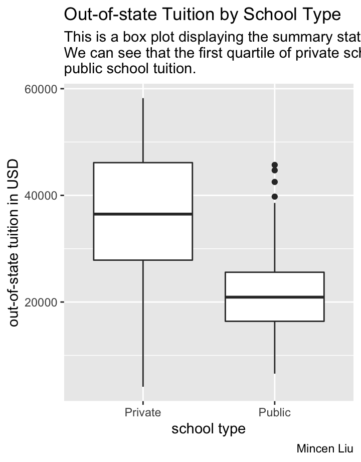

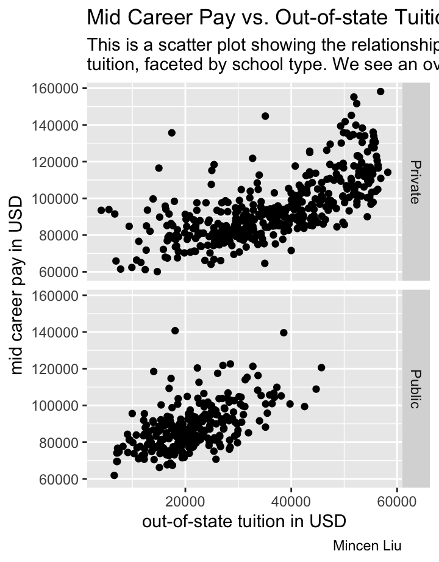

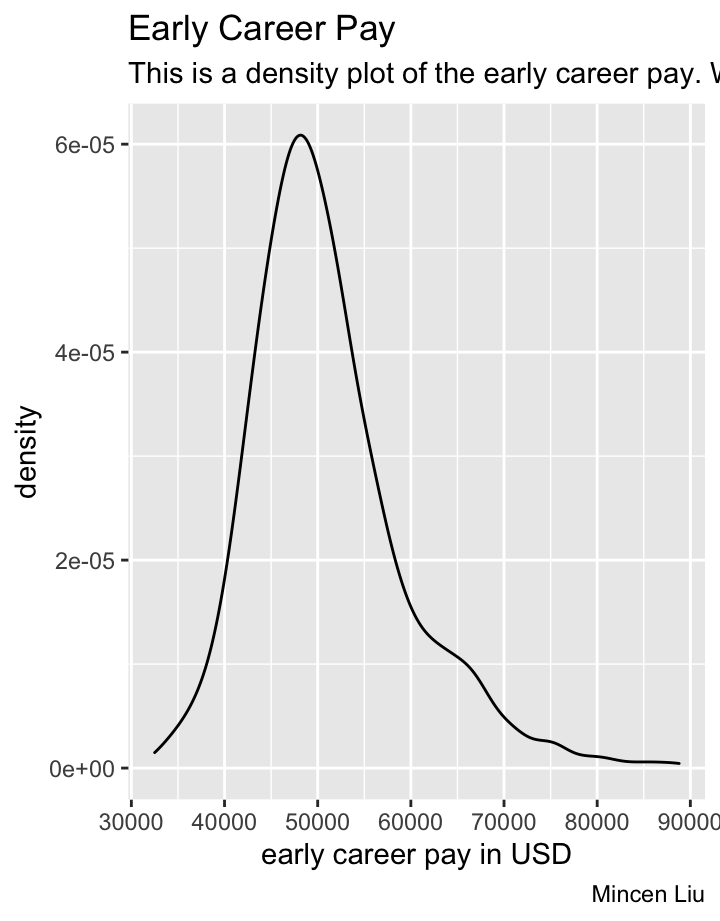

# About

### Purpose of the dashboard

### Original location of the data

- The data originally came from the US Department of Education. I found the data on [TidyTuesday](https://www.tidytuesday.com) and the link to its GitHub repository is https://github.com/rfordatascience/tidytuesday/tree/master/data/2020/2020-03-10.

### Chart A

### Chart B

### Chart C

# Data

- There are 2 datasets: tuition_cost which contains the in-state and out-state tuition for each school and salary_potential which contains early and mid career pay in USD for students in each school.
- Data dictionaries are available here: https://github.com/rfordatascience/tidytuesday/tree/master/data/2020/2020-03-10#tuition_costcsv, https://github.com/rfordatascience/tidytuesday/tree/master/data/2020/2020-03-10#salary_potentialcsv.

# Static 1

# Static 2

# Interactive 1

# Interactive 2

# Analysis

### Data Wrangling

```
integer(0)
```

Luckily, we don’t have any missing values.

```
# A tibble: 135 × 2
   state          state_name
   <chr>          <chr>
 1 New York       New-York
 2 North Carolina North-Carolina
 3 South Dakota   South-Dakota
 4 New York       New-York
 5 North Carolina North-Carolina
 6 North Carolina North-Carolina
 7 South Carolina South-Carolina
 8 South Dakota   South-Dakota
 9 New Jersey     New-Jersey
10 West Virginia  West-Virginia
# … with 125 more rows
```

From here, we see that it is possible that the difference in the 2 columns is caused by the dash in the values of “state_name”. We’re going to check that.

```
# A tibble: 4 × 4
  name                 state      state_code state_name
  <chr>                <chr>      <chr>      <chr>
1 Northwestern College Illinois   IL         Iowa
2 St. John's College   Illinois   IL         Maryland
3 St. John's College   New Mexico NM         Maryland
4 Sterling College     Vermont    VT         Kansas
```

We remove the 4 observations with inconsistent information.

```
# A tibble: 724 × 10
   name      state state…¹ type  degre…² in_st…³ out_o…⁴ early…⁵ mid_c…⁶ stem_…⁷
   <chr>     <chr> <chr>   <chr> <chr>     <dbl>   <dbl>   <dbl>   <dbl>   <dbl>
 1 Adams St… Colo… CO      Publ… 4 Year     9440   20456   44400   81400       3
 2 Adventis… Flor… FL      Priv… 4 Year    15150   15150   51600   89800       5
 3 Agnes Sc… Geor… GA      Priv… 4 Year    41160   41160   46000   83600      26
 4 Alabama … Alab… AL      Publ… 4 Year    11068   19396   39800   71500      16
 5 Alaska P… Alas… AK      Priv… 4 Year    20830   20830   50300   90000       6
 6 Albany C… New … NY      Priv… 4 Year    35105   35105   81000  144800       2
 7 Albertus… Conn… CT      Priv… 4 Year    32060   32060   49700   85900       2
 8 Albion C… Mich… MI      Priv… 4 Year    45775   45775   52100   99300      23
 9 Alcorn S… Miss… MS      Publ… 4 Year     7144    7144   40900   69500      19
10 Allen Co… Iowa  IA      Priv… 4 Year    19970   19970   51600   91300       0
# … with 714 more rows, and abbreviated variable names ¹state_code,
#   ²degree_length, ³in_state_tuition, ⁴out_of_state_tuition,
#   ⁵early_career_pay, ⁶mid_career_pay, ⁷stem_percent
```

```
# A tibble: 2 × 2
  degree_length     n
  <chr>         <int>
1 2 Year            3
2 4 Year          721
```

We keep only the 4-year schools.

```
# A tibble: 721 × 10
   name      state state…¹ type  degre…² in_st…³ out_o…⁴ early…⁵ mid_c…⁶ stem_…⁷
   <chr>     <chr> <chr>   <chr> <chr>     <dbl>   <dbl>   <dbl>   <dbl>   <dbl>
 1 Adams St… Colo… CO      Publ… 4 Year     9440   20456   44400   81400       3
 2 Adventis… Flor… FL      Priv… 4 Year    15150   15150   51600   89800       5
 3 Agnes Sc… Geor… GA      Priv… 4 Year    41160   41160   46000   83600      26
 4 Alabama … Alab… AL      Publ… 4 Year    11068   19396   39800   71500      16
 5 Alaska P… Alas… AK      Priv… 4 Year    20830   20830   50300   90000       6
 6 Albany C… New … NY      Priv… 4 Year    35105   35105   81000  144800       2
 7 Albertus… Conn… CT      Priv… 4 Year    32060   32060   49700   85900       2
 8 Albion C… Mich… MI      Priv… 4 Year    45775   45775   52100   99300      23
 9 Alcorn S… Miss… MS      Publ… 4 Year     7144    7144   40900   69500      19
10 Allen Co… Iowa  IA      Priv… 4 Year    19970   19970   51600   91300       0
# … with 711 more rows, and abbreviated variable names ¹state_code,
#   ²degree_length, ³in_state_tuition, ⁴out_of_state_tuition,
#   ⁵early_career_pay, ⁶mid_career_pay, ⁷stem_percent
```

We want to find the modal value(s) for the percent of student body in STEM:

```
[1] 0 7
```

We can see that the modes are 0 and 7.

### Data Visualization

- Plot 1

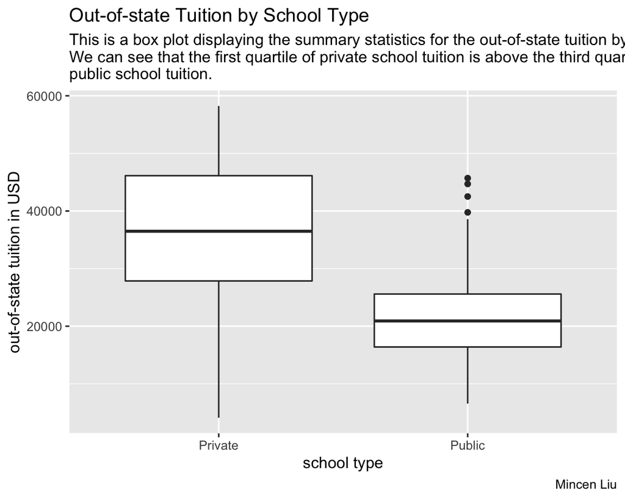

- Plot 2

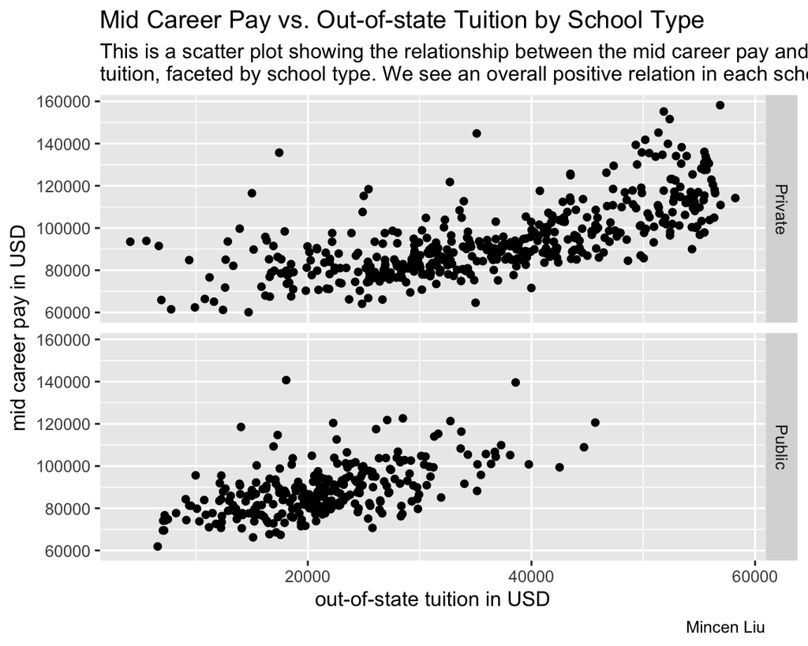

- Plot 3

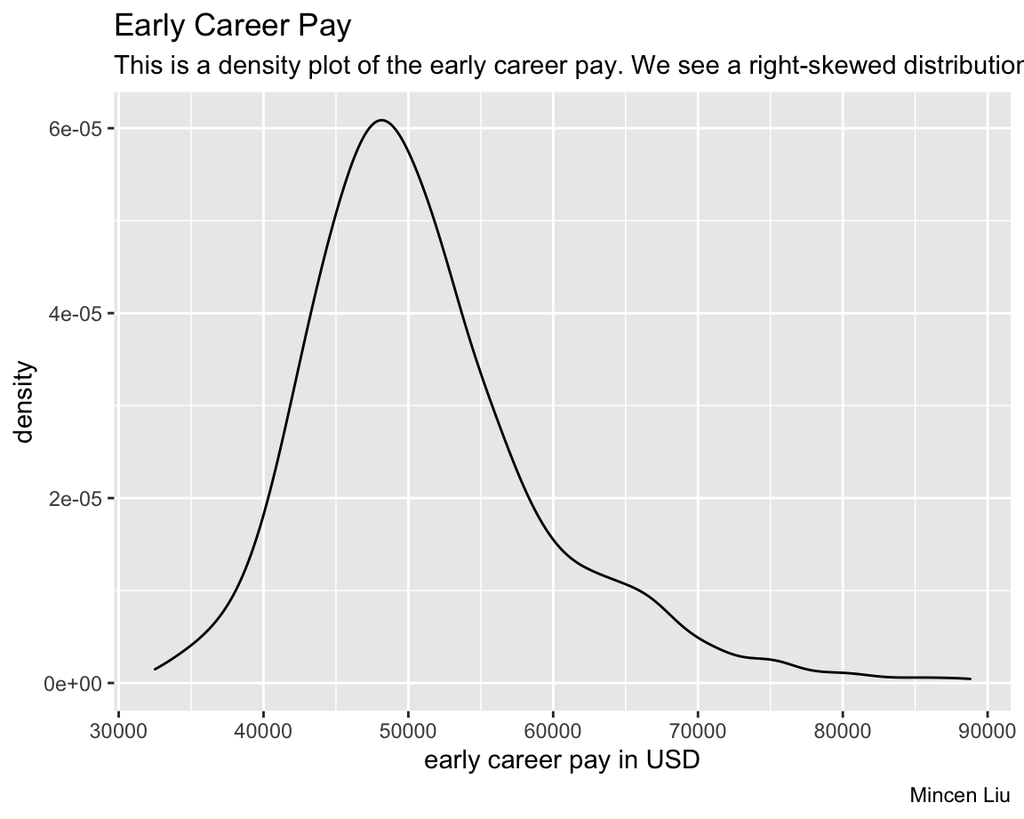

### Interpretation

- On average, private school out-of-state tuition is much higher than public school out-of-state tuition among the 4-year institutions.
- We see an overall positive relation between the mid career pay and the out-of-state tuition in each school type.
- The early career pay has a right-skewed distribution.

### List of Functions Used

- `dplyr`: `glimpse()`, `inner_join()`, `select()`, `slice()`, `count()`, `filter()`
- `stringr`: `str_equal()`, `str_replace()`
- `purrr`: `map2()`, `pmap()`
- `ggplot2`: `geom_boxplot()`, `geom_point()`, `geom_density()`, `facet_grid()`
- `omnibus`: `naRows()`, `mmode()`